# ggplot Multiple Scatter-Lines and Facet Wrap Over Categories

[Fan Wang](https://fanwangecon.github.io/)

2021-04-18

# 1 ggplot Multiple Scatter-Lines with Facet Wrap

> Go to the [**RMD**](https://github.com/FanWangEcon//R4Econ/blob/master/tabgraph/ggscatter//fs_ggscatter_facet_wrap.Rmd), [**R**](https://github.com/FanWangEcon//R4Econ/blob/master/tabgraph/ggscatter//htmlpdfr/fs_ggscatter_facet_wrap.R), [**PDF**](https://github.com/FanWangEcon//R4Econ/blob/master/tabgraph/ggscatter//htmlpdfr/fs_ggscatter_facet_wrap.pdf), or [**HTML**](https://fanwangecon.github.io//R4Econ/tabgraph/ggscatter//htmlpdfr/fs_ggscatter_facet_wrap.html) version of this file. Go back to [fan](http://fanwangecon.github.io/)’s [REconTools](https://fanwangecon.github.io/REconTools/) Package, [R Code Examples](https://fanwangecon.github.io/R4Econ/) Repository ([bookdown site](https://fanwangecon.github.io/R4Econ/bookdown)), or [Intro Stats with R](https://fanwangecon.github.io/Stat4Econ/) Repository ([bookdown site](https://fanwangecon.github.io/Stat4Econ/bookdown)).

## 1.1 Multiple Scatter-Lines with Facet Wrap

First, Load in the mtcars dataset and convert to categorical variables to factor with labels.

```r
# First make sure these are factors
tb_mtcars <- as_tibble(mtcars) %>%
  mutate(vs = as_factor(vs), am = as_factor(am))
# Second Label the Factors
am_levels <- c(auto_shift = "0", manual_shift = "1")
vs_levels <- c("vshaped engine" = "0", "straight engine" = "1")
tb_mtcars <- tb_mtcars %>%
  mutate(vs = fct_recode(vs, !!!vs_levels),
         am = fct_recode(am, !!!am_levels))
```

```r
# Graphing
plt_mtcars_scatter <-
  ggplot(tb_mtcars, aes(x=hp, y=qsec,
                        colour=am, shape=am, linetype=am)) +
  geom_smooth(se = FALSE, lwd = 1.5) + # Lwd = line width
  geom_point(size = 5, stroke = 2) + # stroke = point shape width
  facet_wrap(~ vs,
             scales = "free_x",
             nrow = 1, ncol = 2,
             labeller = label_wrap_gen(multi_line=FALSE))
```

Third, control Color, Shape and Line-type Information. There will be two colors, two shapes and two linetypes. See all [shape listing](https://www.google.com/search?q=r+points+shapes&oq=r+point+shapes) and [linetype listing](https://www.google.com/search?q=r+points+shapes&oq=r+point+shapes)., See all [shape listing](https://www.google.com/search?q=r+linetype&oq=r+linetype).

```r
# Color controls
ar_st_colors <- c("#33cc33", "#F8766D")
ar_st_colors_label <- c("auto", "manual")
fl_legend_color_symbol_size <- 5
st_leg_color_lab <- "Transmission"
# Shape controls
ar_it_shapes <- c(1, 5)
ar_st_shapes_label <- c("auto", "manual")
fl_legend_shape_symbol_size <- 5
st_leg_shape_lab <- "Transmission"
# Line-Type controls
ar_st_linetypes <- c('solid', 'dashed')
ar_st_linetypes_label <- c("auto", "manual")
fl_legend_linetype_symbol_size <- 5
st_leg_linetype_lab <- "Transmission"
```

Fourth, manaully specify an x-axis.

```r
# x labeling and axis control
ar_st_x_labels <- c('50 hp', '150 hp', '250 hp', '350 hp')
ar_fl_x_breaks <- c(50, 150, 250, 350)
ar_fl_x_limits <- c(40, 360)
# y labeling and axis control
ar_st_y_labels <- c('15 QSEC', '18', '21', '24 QSEC')
ar_fl_y_breaks <- c(15, 18, 21, 24)
ar_fl_y_limits <- c(13.5, 25.5)
```

Fifth, control graph strings.

```r
# Labeling
st_title <- paste0('How QSEC varies by Horse-power, by Engine and Transmission Types')
st_subtitle <- paste0('https://fanwangecon.github.io/',
                      'R4Econ/tabgraph/multiplot/htmlpdfr/fs_ggscatter_facet_wrap.html')
st_caption <- paste0('mtcars dataset, ',
                     'https://fanwangecon.github.io/R4Econ/')
st_x_label <- 'HP = Horse Power'
st_y_label <- 'QSEC = time for 1/4 Miles'
```

Sixth, combine graphical components.

```r
# Add titles and labels
plt_mtcars_scatter <- plt_mtcars_scatter +
  labs(title = st_title, subtitle = st_subtitle,
       x = st_x_label, y = st_y_label, caption = st_caption)

# x and y-axis ticks controls
plt_mtcars_scatter <- plt_mtcars_scatter +
  scale_x_continuous(labels = ar_st_x_labels,
                     breaks = ar_fl_x_breaks,
                     limits = ar_fl_x_limits) +
  scale_y_continuous(labels = ar_st_y_labels,
                     breaks = ar_fl_y_breaks,
                     limits = ar_fl_y_limits)

# Color, shape and linetype controls
plt_mtcars_scatter <- plt_mtcars_scatter +
  scale_colour_manual(values=ar_st_colors, labels=ar_st_colors_label) +
  scale_shape_manual(values=ar_it_shapes, labels=ar_st_shapes_label) +
  scale_linetype_manual(values=ar_st_linetypes, labels=ar_st_linetypes_label)
```

Seventh, replace default legends, and set figure font overall etc.

```r
# has legend theme
theme_custom <- theme(
  text = element_text(size = 11),
  axis.text.y = element_text(angle = 90),
  legend.title = element_blank(),
  legend.position = c(0.35, 0.80),
  legend.key.width = unit(5, "line"),
  legend.background =
    element_rect(fill = "transparent", colour = "black", linetype='solid'))
# no legend theme (no y)
theme_custom_blank <- theme(
  text = element_text(size = 12),
  legend.title = element_blank(),
  legend.position = "none",
  axis.title.y=element_blank(),
  axis.text.y=element_blank(),
  axis.ticks.y=element_blank())
```

Eighth, graph out.

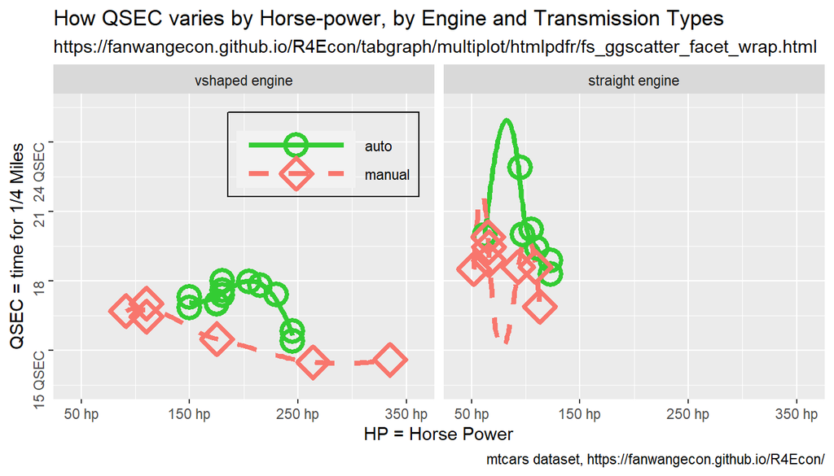

```r
# replace the default labels for each legend segment
plt_mtcars_scatter <- plt_mtcars_scatter + theme_custom
# show
print(plt_mtcars_scatter)
```

## 1.2 Divide Facet Wrapped Plot into Subplots

Below generate a matrix with multiple data columns, then use apply over each row of the matrix and select different columns of values for each subplot generation.

First generate with legend versions, then without legend versions. These are versions that would be used to more freely compose graph together.

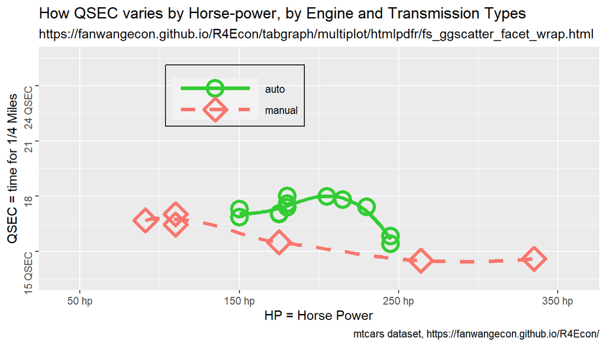

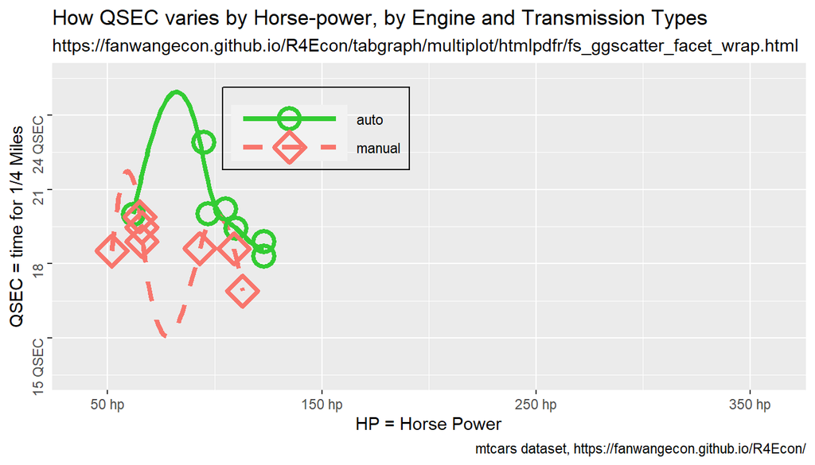

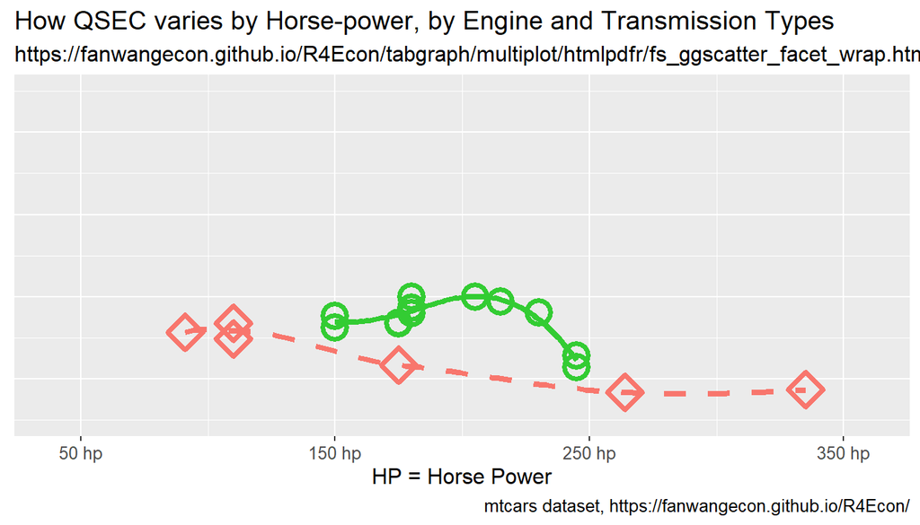

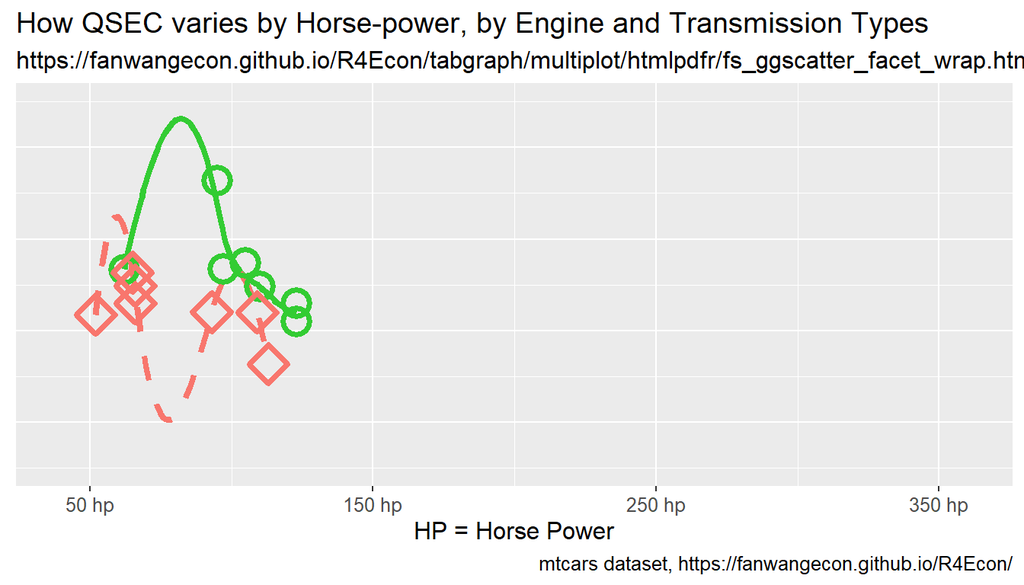

```r
for (it_subplot_as_own_vsr in c(1,2)) {

  if (it_subplot_as_own_vsr == 1) {
    theme_custom_use <- theme_custom
    # st_file_suffix <- '_haslegend'
    # it_width <- 100
  } else if (it_subplot_as_own_vsr == 2) {
    theme_custom_use <- theme_custom_blank
    # st_file_suffix <- '_nolegend'
    # it_width <- 88
  }

  # unique vs as matrix
  # ar_uniques <-sort(unique(tb_mtcars$vs))
  # mt_unique_vs <- matrix(data=ar_uniques, nrow=length(ar_uniques), ncol=1)
  mt_unique_vs <- tb_mtcars %>% group_by(vs) %>%
    summarize(mpg=mean(mpg)) %>% ungroup()
  # apply over
  ls_plots <- apply(mt_unique_vs, 1, function(ar_vs_cate_row) {
    # 1. Graph main
    plt_mtcars_scatter <-
      ggplot(tb_mtcars %>% filter(vs == ar_vs_cate_row[1]),
             aes(x=hp, y=qsec,
                 colour=am, shape=am, linetype=am)) +
      geom_smooth(se = FALSE, lwd = 1.5) + # Lwd = line width
      geom_point(size = 5, stroke = 2)

    # 2. Add titles and labels
    plt_mtcars_scatter <- plt_mtcars_scatter +
      labs(title = st_title, subtitle = st_subtitle,
           x = st_x_label, y = st_y_label, caption = st_caption)

    # 3. x and y ticks
    plt_mtcars_scatter <- plt_mtcars_scatter +
      scale_x_continuous(labels = ar_st_x_labels, breaks = ar_fl_x_breaks, limits = ar_fl_x_limits) +
      scale_y_continuous(labels = ar_st_y_labels, breaks = ar_fl_y_breaks, limits = ar_fl_y_limits)

    # 4. Color, shape and linetype controls
    plt_mtcars_scatter <- plt_mtcars_scatter +
      scale_colour_manual(values=ar_st_colors, labels=ar_st_colors_label) +
      scale_shape_manual(values=ar_it_shapes, labels=ar_st_shapes_label) +
      scale_linetype_manual(values=ar_st_linetypes, labels=ar_st_linetypes_label)

    # 5. replace the default labels for each legend segment
    plt_mtcars_scatter <- plt_mtcars_scatter + theme_custom_use
  })
  # show
  print(ls_plots)
}
```